# homework_05_Hua Ji

## CMPINF 2120: Homework 05

## Assigned: Tuesday of Week 05 at 11:00PM

## DUE: Tuesday of Week 06 at 11:59PM

This assignment is focused on generating features from numeric inputs for linear models. You will get extensive practice deriving linear, non-linear, additive, and interaction features using the formula interface with `dmatrices()` and `statsmodels`. It involves many repetitive and tedious tasks. That is by design! One of the goals of the assignment is for you to see how similar many of the actions are, even when the data change across applications!

You will work with one synthetic data set created specifically for this assignment, as well as a real data set. The synthetic data set gives you experience generating features, fitting models, and interpreting the models through coefficients and predictions. The synthetic data set consists of a single numeric input which simplifies visualization and interpretation. The real data set involves multiple inputs and requires you to develop preprocessing pipelines before generating the features from the inputs.

You are required to create specific features for each problem. Although you fit multiple models, this assignment does **not** deal with identifying the best model. That topic is reserved for a later assignment. Because this assignment is focused on **features** you will only fit and interpret models for the synthetic data set in this assignment. Fitting models for the real data set are reserved for later assignments.

You may add as many code and markdown cells as you see fit to answer the questions.

### Collaborators

Type the names of other students you worked with here.

## Problem 00

Let's import all required modules and functions for this assignment upfront.

### 0a)

Import the "big 4" data analysis modules of NumPy, Pandas, matplotlib pyplot, and Seaborn. You **must** use their common aliases.

#### 0a) - SOLUTION

```python
import numpy as np
import pandas as pd
import matplotlib.pyplot as plt

import seaborn as sns
```

### 0b)

You will fit linear models via `statsmodels` and create feature arrays using `dmatrices()`.

Import the statsmodels formula interface using its common alias. Import the `dmatrices()` function from the appropriate module.

#### 0b) - SOLUTION

```python
import statsmodels.formula.api as smf
from patsy import dmatrices
```

### 0c)

You will use scikit-learn functions to preprocess inputs later in the assignment. You will manage your preprocessing actions within preprocessing pipelines via the Pipelines module.

Import the `StandardScaler()` and `QuantileTransformer()` functions from the appropriate scikit-learn modules. Import the `Pipeline()` function from the appropriate scikit-learn module.

#### 0c) - SOLUTION

```python
from sklearn.preprocessing import StandardScaler
from sklearn.preprocessing import QuantileTransformer
from sklearn.pipeline import Pipeline
```

## Problem 01

The synthetic data involves a single numeric input. One input is used to support visualization and easily displaying results to the screen. This will give you first hand experience working with the linear modeling functions without getting bogged down in the challenges associated with multiple input problems. Please pay close attention to the function syntax and the strategy outlined in the problem statements. You will notice patterns that carry over to more challenging problems!

### 1a)

The synthetic data file name is assigned to the `probA_path` object in the cell below. The file name assumes that you have downloaded the `hw05_probA.csv` file into the same working directory as this notebook.

```python
probA_path = 'hw05_probA.csv'
```

The data set consists of 2 columns. The `x` column is the single numeric input and the `y` column is the single numeric output.

Read in the data using the appropriate Pandas function and assign the result to the `dfA` object. Display the `.info()` method to confirm the data have been read in correctly.

#### 1a) - SOLUTION

```python
dfA=pd.read_csv(probA_path)
```

```python
dfA.info()
```

```
<class 'pandas.core.frame.DataFrame'>
RangeIndex: 201 entries, 0 to 200
Data columns (total 2 columns):
 #   Column  Non-Null Count  Dtype
---  ------  --------------  -----
 0   x       201 non-null    float64
 1   y       201 non-null    float64
dtypes: float64(2)
memory usage: 3.3 KB
```

### 1b)

Let's do a quick exploration of the data. Visualize the marginal distribution for the input `x` via a histogram. Visuaize the marginal distribution for the output `y` via a histogram. Both histograms must be created using Seaborn.

#### 1b) - SOLUTION

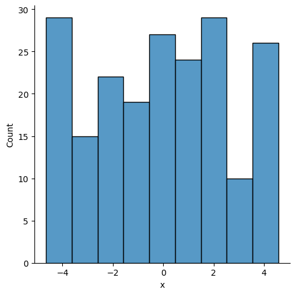

```python
sns.displot(dfA, x='x', kind ='hist')
plt.show()
```

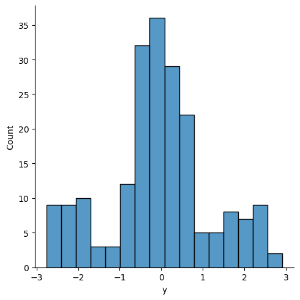

```python
sns.displot(dfA, x='y', kind='hist')
plt.show()
```

### 1c)

Next, let's examine the relationship between the output and input via a scatter plot. Create the scatter plot using Seaborn.

#### 1c) - SOLUTION

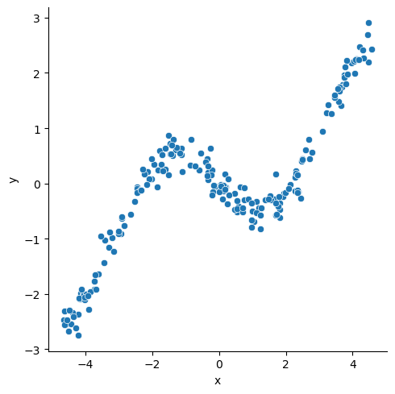

```python
sns.relplot(dfA, x='x', y='y')
plt.show()
```

### 1d)

Create a trend plot that includes a linear trend line ("best fit line") on top of the scatter plot between the output and the input. The trend plot must be created using Seaborn.

#### 1d) - SOLUTION

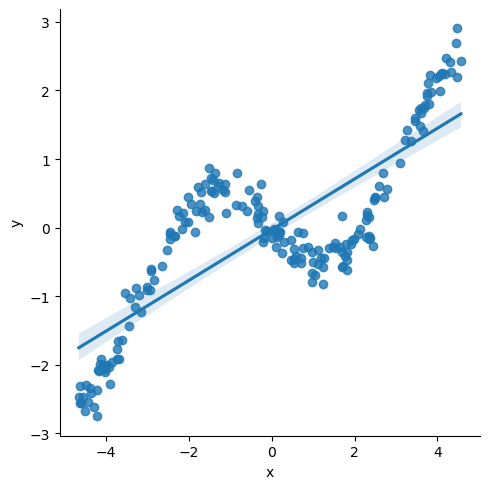

```python
sns.lmplot(dfA, x='x',y='y')
plt.show()
```

### 1e)

Please describe the output to input relationship. Does it appear linear? Is it non-linear? Does the linear trend line capature the variation of the output given the input?

Please type your response in a markdown cell below.

#### 1e) - SOLUTION

The output and input is not a linear relationship. The linear trend line doesn't capture the variation of the output given the input.

## Problem 02

The `dfA` data set is a predictive modeling application. The ultimate goal is to train models to predict the output `y` given the input `x`. This assignment is focused on **linear models** for regression. You already explored the output to input relationship, but linear models can do **more** than just straight lines! Therefore, you must examine the behavior of possible features you **could** derive from the numeric input.

This problem is focused on examining the features derived from the input `x`. You will use `dmatrices()` to generate the feature arrays using the formula interface. You **must** return Pandas DataFrames from the `dmatrices()` functionc all to support easy manipulation of the features.

You are **not** fitting models in the problem. You are generating features and examining those features **before** fitting models.

### 2a)

As discussed in lecture, it is best to always start simple! Therefore, you will begin with the simplest possible linear model, the INTERCEPT-ONLY or unknown constant average model!

You must generate the output and input feature arrays for an INTERCEPT-ONLY model for `dfA` using `dmatrices()` and the formula interface. The output array must be assigned to the `yA_df_0` object and the input feature array must be assigned to the `XA_df_0` object. You **must** return Pandas DataFrames from `dmatrices()`.

Display the `.head()` of each Pandas DataFrame to the screen.

#### 2a) - SOLUTION

```python
yA_df_0, XA_df_0=dmatrices('y~1', data =dfA,return_type='dataframe')
```

```python
yA_df_0.head()
```

|  | y |
| --- | --- |
| 0 | 2.107581 |
| 1 | -2.371664 |
| 2 | -0.512425 |
| 3 | -2.348134 |
| 4 | 0.546149 |

```python
XA_df_0.head()
```

|  | Intercept |
| --- | --- |
| 0 | 1.0 |
| 1 | 1.0 |
| 2 | 1.0 |
| 3 | 1.0 |
| 4 | 1.0 |

### 2b)

How many columns are associated with the `XA_df_0` feature array? What are the unique values associated with the columns?

Why do the columns have those specific unique values?

Display your answers via code cells below and type your response to the question within a markdown cell.

#### 2b) - SOLUTION

```python
XA_df_0.shape
```

```
(201, 1)
```

```python
XA_df_0.nunique()
```

```
Intercept    1
dtype: int64
```

There is only one column in the feature arrays. The unique value associated with the columns is 1. Because this is the intercept column, the intercpet 1 * the coefficient is the real intercept.

### 2c)

You must now add complexity by including the input `x` in the formula for the model. The formula must involve a linear relationship between the output and the input. Therefore, you are creating the feature array associated with the classic "best fit line".

The output array must be assigned to the `yA_df_1` object and the input feature array must be assigned to the `XA_df_1` object. You must return Pandas DataFrames from `dmatrices()`.

Display the `.head()` of the `XA_df_1` DataFrame to the screen.

#### 2c) - SOLUTION

```python
yA_df_1,XA_df_1=dmatrices('y~x', data=dfA, return_type='dataframe')
```

```python
XA_df_1.head()
```

|  | Intercept | x |
| --- | --- | --- |
| 0 | 1.0 | 3.774523 |
| 1 | 1.0 | -4.218102 |
| 2 | 1.0 | 0.547622 |
| 3 | 1.0 | -4.384318 |
| 4 | 1.0 | -0.554832 |

### 2d)

How many coefficients must be estimated for the model associated with the features contained in `XA_df_1`? What are the interpretations of the coefficients multiplying the features contained in `XA_df_1`?

Type your response in a markdown cell below.

#### 2d) - SOLUTION

two coefficients must be estimted for the model associated with the features contained in XA_df_1. one is the coefficient for the intercept and the other is the coefficient for the variable.

### 2e)

Let's now derive a non-linear feature from the numeric input. Specifically, you must create the feature array that relates the output to the sine function, `np.sin()`, applied to the numeric input, `x`. You are **not** including the linear feature in this question. Instead, the output is related **directly** to the sine function applied to the numeric input.

The output array must be assigned to the `yA_df_2` object and the input feature array must be assigned to the `XA_df_2` object. You must return Pandas DataFrames from `dmatrices()`.

Display the `.head()` of the `XA_df_2` DataFrame to the screen.

#### 2e) - SOLUTION

```python
yA_df_2,XA_df_2=dmatrices('y~np.sin(x)', data =dfA, return_type='dataframe')
```

```python
XA_df_2.head()
```

|  | Intercept | np.sin(x) |
| --- | --- | --- |
| 0 | 1.0 | -0.591510 |
| 1 | 1.0 | 0.880307 |
| 2 | 1.0 | 0.520659 |
| 3 | 1.0 | 0.946666 |
| 4 | 1.0 | -0.526801 |

### 2f)

How many coefficients must be estimated for the model associated with the features contained in `XA_df_2`? What are the interpretations of the coefficients multiplying each feature contained in `XA_df_2`?

Type your response in a markdown cell below.

#### 2f) - SOLUTION

two coefficients must be estimated for the model associated with the features contained in XA_df_2. The two coefficients are the one for the intercept and the other one for the sin(x)

### 2g)

The formula interface is quite flexible. You can derive as many features as you want from the inputs. Let's demonstrate this by creating the feature array associated with **adding** the linear feature to the sine-function, `np.sin()`, feature. Thus, you are deriving multiple features from the **same** input!

The output array must be assigned to the `yA_df_3` object and the input feature array must be assigned to the `XA_df_3` object. You must return Pandas DataFrames from `dmatrices()`.

Display the `.head()` of the `XA_df_3` DataFrame to the screen.

#### 2g) - SOLUTION

```python
yA_df_3, XA_df_3=dmatrices('y~x+np.sin(x)',data =dfA, return_type='dataframe')
```

```python
XA_df_3.head()
```

|  | Intercept | x | np.sin(x) |
| --- | --- | --- | --- |
| 0 | 1.0 | 3.774523 | -0.591510 |
| 1 | 1.0 | -4.218102 | 0.880307 |
| 2 | 1.0 | 0.547622 | 0.520659 |
| 3 | 1.0 | -4.384318 | 0.946666 |
| 4 | 1.0 | -0.554832 | -0.526801 |

### 2h)

How many coefficients must be estimated for the model associated with the features contained in `XA_df_3`? What are the interpretations of the coefficients multiplying each feature contained in `XA_df_3`?

Type your response in a markdown cell below.

#### 2h) - SOLUTION

Three coefficients muste be esitmated for the model associated with the features contained in XA_df_e. one coefficient is for the intercept, the second one is for the variable x and the rest one is for sin(x)

### 2i)

Adding features is one way of including more features in a model. Another approach is to consider multiplicative or **interactions** between features. The last set of features you will examine are those associated with the product of the linear feature and the sine-function feature, `np.sin()`. This model **must** include the **main effects** and the **interactions** between the linear and sine-function features. You are allowed to use either shortcut within the formula interface for creating the main effects and interactions.

The output array must be assigned to the `yA_df_4` object and the input feature array must be assigned to the `XA_df_4` object. You must return Pandas DataFrames from `dmatrices()`.

Display the `.head()` of the `XA_df_4` DataFrame to the screen.

#### 2i) - SOLUTION

```python
yA_df_4,XA_df_4=dmatrices('y~x*np.sin(x)', data =dfA, return_type='dataframe')
```

```python
XA_df_4.head()
```

|  | Intercept | x | np.sin(x) | x:np.sin(x) |
| --- | --- | --- | --- | --- |
| 0 | 1.0 | 3.774523 | -0.591510 | -2.232667 |
| 1 | 1.0 | -4.218102 | 0.880307 | -3.713225 |
| 2 | 1.0 | 0.547622 | 0.520659 | 0.285124 |
| 3 | 1.0 | -4.384318 | 0.946666 | -4.150483 |
| 4 | 1.0 | -0.554832 | -0.526801 | 0.292286 |

### 2j)

Which of the columns in `XA_df_4` corresponds to the **product** between the linear feature and the sine-function feature?

How many coefficients must be estimated for the model associated with the features contained in `XA_df_4`? What are the interpretations of the coefficients multiplying each feature contained in `XA_df_4`?

Type your response in a markdown cell below.

#### 2j) - SOLUTION

The x:np.sin(x) column is corresponds to the product between the linear feature and the sinc-function feature. Four coefficient must be estimated for the model associated with the features contained in XA_df_4. The intercept coefficient, the coefficient related with x, the coefficient related with np.sin(x) and the coefficient related with x*np.sin(x)

## Problem 03

You will fit models associated with each of the set of features you examined in the previous problem. You will use the `smf.ols()` function and the formula interface to git the models. Thus, you will **not** use the feature arrays created in the previous problem. They served the purpose of letting you examine the features **before** fitting the models so that you may know how many coefficients must be estimated for each model.

You are required to visually confirm statistical significance for each model. However, you are allowed to the p-values to quantitatvely check if you are not sure based on the figure alone.

### 3a)

However, before fitting the models. Let's define a function to help interpret the coefficients. The lecture examples defined a function, `my_coefplot()`, that created a coefficient plot for a statsmodels fit model.

You must define the `my_coefplot()` function in the cell below. You will use it for the remainder of the assignment.

*NOTE*: This should **not** be the `my_coefplot_b()` function which allows removing the Intercept from the figure.

#### 3a) - SOLUTION

```python
def my_coefplot(mod, figsize_use=(10,4)):
    fig,ax=plt.subplots(figsize=figsize_use)
    ax.errorbar(y=mod.params.index,
                x=mod.params,
                xerr = 2*mod.bse,
                fmt='o', color='k',ecolor='k', elinewidth=2, ms=10)
    ax.axvline(x=0, linestyle='--', color='grey',linewidth=3.5)
    ax.set_xlabel('coefficient value')
    plt.show()
```

### 3b)

Let's start with the simplest model.

Fit the INTERCEPT-ONLY model using the formula interface and assign the result to the `fit_A_0` object.

Display the coefficient plot after fitting the model.

#### 3b) - SOLUTION

```python
fit_A_0=smf.ols(formula='y~1',data =dfA).fit()
```

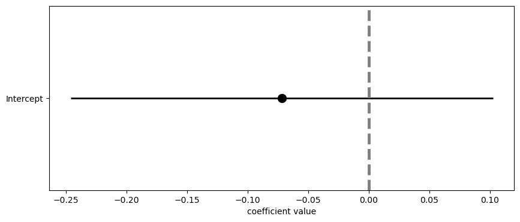

```python
my_coefplot(fit_A_0)
```

### 3c)

Next, fit the model with the linear relationship between the output and the input (the classic "best fit line").

Assign the result to the `fit_A_1` object.

Display the coefficient plot after fitting the model.

Is the input statistically significant?

#### 3c) - SOLUTION

```python
fit_A_1 =smf.ols('y~x', data =dfA).fit()
```

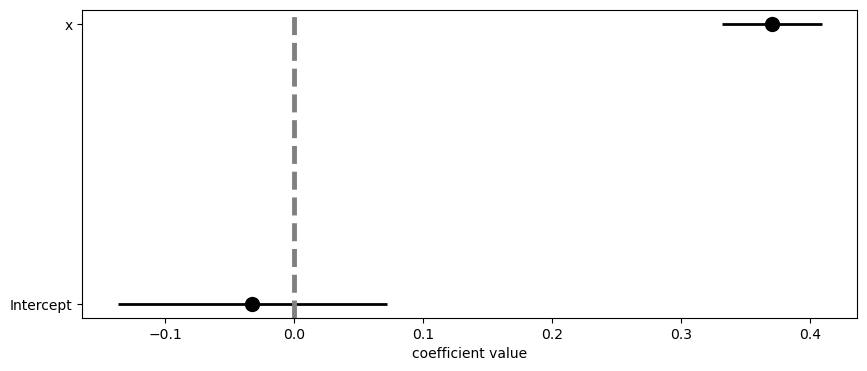

```python
my_coefplot(fit_A_1)
```

Since the coefficient of the input does not pass the 0, we can see that it is statistically significant.

### 3d)

Next, fit the model "sine function model" that directly relates the output to the sine-function, `np.sin()`, applied to the input, `x`.

Assign the result to the `fit_A_2` object.

Display the coefficient plot after fitting the model.

Is the sine-function statistically significant?

#### 3d) - SOLUTION

```python
fit_A_2=smf.ols('y~np.sin(x)', data=dfA).fit()
```

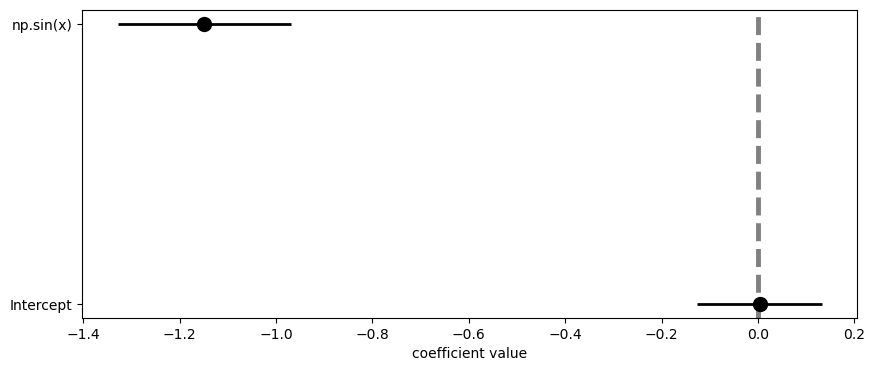

```python
my_coefplot(fit_A_2)
```

### 3e)

Next, fit the model that **adds** the linear feature to the sine-function feature.

Assign the result to the `fit_A_3` object.

Display the coefficient plot after fitting the model.

Which features are statistically significant?

#### 3e) - SOLUTION

```python
fit_A_3=smf.ols('y~x+np.sin(x)', data=dfA).fit()
```

```python
fit_A_3.conf_int()
```

|  | 0 | 1 |
| --- | --- | --- |
| Intercept | 0.003244 | 0.054593 |
| x | 0.328016 | 0.347298 |
| np.sin(x) | -1.031931 | -0.960487 |

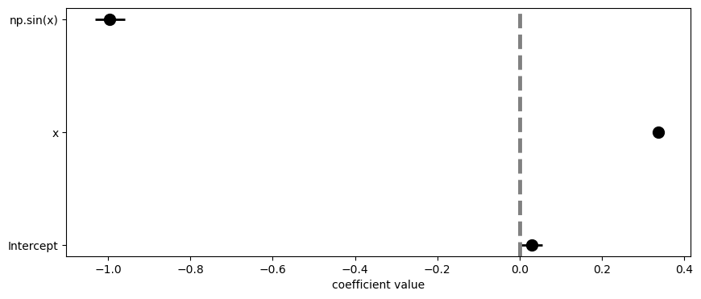

```python
my_coefplot(fit_A_3)
```

The intercept, the input x and sine-function features are statistically significant.

### 3f)

Lastly, fit the model that includes the **main effects** and **interaction** for the linear and sine-function features.

Assign the result to the `fit_A_4` object.

Display the coefficient plot after fitting the model.

Which features statistically significant?

#### 3f) - SOLUTION

```python
fit_A_4=smf.ols('y~x*np.sin(x)', data=dfA).fit()
```

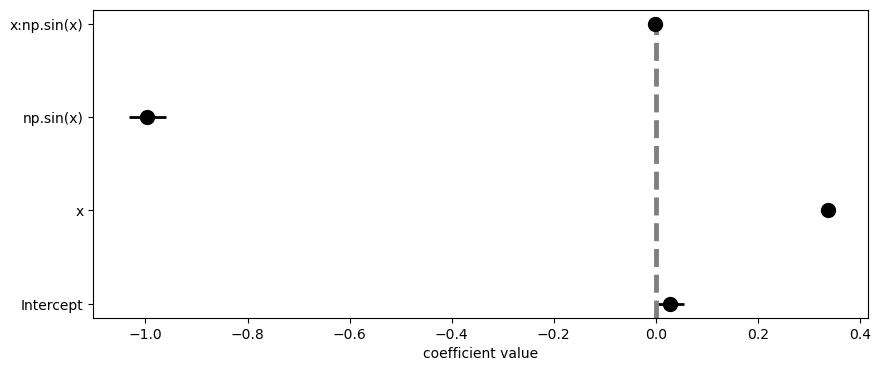

```python
my_coefplot(fit_A_4)
```

The intercept, the input and the sine-function features are all statistically significant.

### 3g)

You fit models with different numbers of coefficients. However, you **should** have known the number of coefficients associated with model because of Problem 02.

**How** did the feature array let you know the number of coefficients associated with each model?

Type your response in a markdown cell below.

#### 3g) - SOLUTION

The number of coefficients that the feature arrays want us to predict is the same with the number of coefficient that the fitted model has shown.

## Problem 04

Coefficients help you interpret model behavior. However, it can still be tricky to understand just **how** the output will behave. Coefficient summaries therefore need to be supplemented with predictions to fully understand how the output relates to the input.

You will create predictions on **new** data in this problem. You will define your own data set to support visualizing the output to input relationship. However, you will not simply visualize the trend. You will also represent the uncertainty by including the **confidence interval** and **prediction interval** with the trend. You will create the visualizations with matplotlib directly, rather than Seaborn in this problem.

This problem is quite repetitive. This is so that you may see the common steps for making and visualization predictions.

### 4a)

A new data set must be defined before predictions can be made. This data set will consist of **evenly** spaced points between a lower bound and upper bound for the numeric input.

Create a DataFrame, `dfA_viz`, that consists of a single column named `x`. The column `x` must consist of 251 evenly spaced points between the training set minimum and maximum associated with `x`.

Display the number of unique values associated with each column in `dfA_viz`.

#### 4a) - SOLUTION

```python
dfA_viz=pd.DataFrame({'x':np.linspace(dfA.x.min(), dfA.x.max(),num=251)})
```

```python
dfA_viz.nunique()
```

```
x    251
dtype: int64
```

### 4b)

You will begin by making predictions on the new data set, `dfA_viz`, with the INTERCEPT-ONLY model, `fit_A_0`.

You must use the appropriate methods to return the predictive trend (mean), the lower and upper bounds on the confidence interval, and the lower and upper bounds on the prediction interval. Assign the predictive summaries to the `pred_viz_A_summary_0` object.

Display the `.head()` associated with `pred_viz_A_summary_0` to the screen.

#### 4b) - SOLUTION

```python
pred_viz_A_summary_0=fit_A_0.get_prediction(dfA_viz).summary_frame()
```

```python
pred_viz_A_summary_0.head()
```

|  | mean | mean_se | mean_ci_lower | mean_ci_upper | obs_ci_lower | obs_ci_upper |
| --- | --- | --- | --- | --- | --- | --- |
| 0 | -0.071665 | 0.087184 | -0.243582 | 0.100252 | -2.515065 | 2.371734 |
| 1 | -0.071665 | 0.087184 | -0.243582 | 0.100252 | -2.515065 | 2.371734 |
| 2 | -0.071665 | 0.087184 | -0.243582 | 0.100252 | -2.515065 | 2.371734 |
| 3 | -0.071665 | 0.087184 | -0.243582 | 0.100252 | -2.515065 | 2.371734 |
| 4 | -0.071665 | 0.087184 | -0.243582 | 0.100252 | -2.515065 | 2.371734 |

### 4c)

You must now visualize the predictions associated with `fit_A_0` on the new data set.

You must include the prediction interval as an orange ribbon, the confidence interval as a grey ribbon, and the predictive trend (mean) as a black line.

Include the training points as small red markers from a scatter plot.

Is the predictive trend consistent with the features associated with `fit_A_0`?

Comment on the prediction interval size relative to the confidence interval size.

#### 4c) - SOLUTION

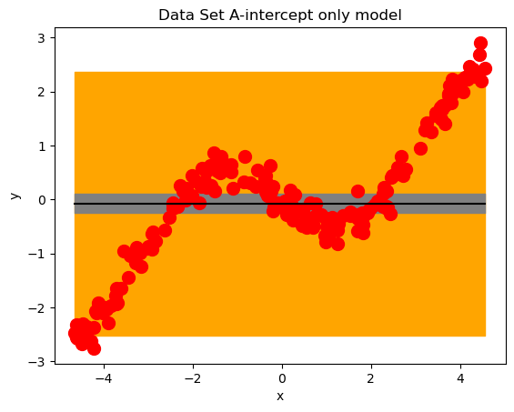

```python
# visualize the predictive trends with uncertainty
fig,ax=plt.subplots()
ax.fill_between(dfA_viz.x,
                pred_viz_A_summary_0.obs_ci_lower, pred_viz_A_summary_0.obs_ci_upper,
                facecolor='orange',edgecolor='orange')
ax.fill_between(dfA_viz.x,
                pred_viz_A_summary_0.mean_ci_lower, pred_viz_A_summary_0.mean_ci_upper,
                facecolor='grey', edgecolor='grey')
ax.plot(dfA_viz.x, pred_viz_A_summary_0['mean'], color='black')
ax.scatter(dfA.x, dfA.y, color='r',s=100)
ax.set_xlabel('x')
ax.set_ylabel('y')
ax.set_title('Data Set A-intercept only model')
plt.show()
```

### 4d)

Next, you must make predictions on the new data set, `dfA_viz`, with the linear relationship model `fit_A_1`.

You must use the appropriate methods to return the predictive trend (mean), the lower and upper bounds on the confidence interval, and the lower and upper bounds on the prediction interval. Assign the predictive summaries to the `pred_viz_A_summary_1` object.

Display the `.head()` associated with `pred_viz_A_summary_1` to the screen.

#### 4d) - SOLUTION

```python
pred_viz_A_summary_1=fit_A_1.get_prediction(dfA_viz).summary_frame()
```

```python
pred_viz_A_summary_1.head()
```

|  | mean | mean_se | mean_ci_lower | mean_ci_upper | obs_ci_lower | obs_ci_upper |
| --- | --- | --- | --- | --- | --- | --- |
| 0 | -1.754355 | 0.102904 | -1.957276 | -1.551433 | -3.226568 | -0.282142 |
| 1 | -1.740701 | 0.102284 | -1.942401 | -1.539002 | -3.212747 | -0.268656 |
| 2 | -1.727048 | 0.101665 | -1.927528 | -1.526568 | -3.198927 | -0.255169 |
| 3 | -1.713395 | 0.101048 | -1.912657 | -1.514132 | -3.185108 | -0.241681 |
| 4 | -1.699741 | 0.100432 | -1.897790 | -1.501693 | -3.171291 | -0.228192 |

### 4e)

You must now visualize the predictions associated with `fit_A_1` on the new data set.

You must include the prediction interval as an orange ribbon, the confidence interval as a grey ribbon, and the predictive trend (mean) as a black line.

Include the training points as small red markers from a scatter plot.

Is the predictive trend consistent with the features associated with `fit_A_1`?

Comment on the prediction interval size relative to the confidence interval size.

#### 4e) - SOLUTION

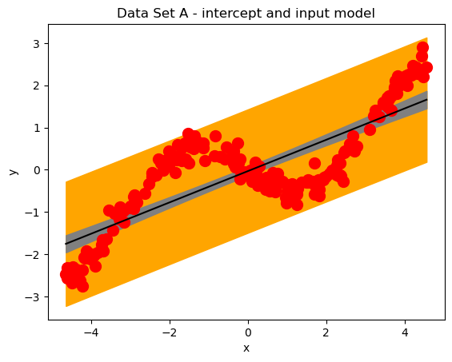

```python
fig, ax = plt.subplots()

# prediction interval
ax.fill_between( dfA_viz.x,
                 pred_viz_A_summary_1.obs_ci_lower, pred_viz_A_summary_1.obs_ci_upper,
                 facecolor='orange', edgecolor='orange')

# confidence interval
ax.fill_between( dfA_viz.x,
                 pred_viz_A_summary_1.mean_ci_lower, pred_viz_A_summary_1.mean_ci_upper,
                 facecolor='grey', edgecolor='grey')

# predicted TREND - average output
ax.plot( dfA_viz.x, pred_viz_A_summary_1['mean'], color='k' )

# include the training data as a scatter plot
ax.scatter( dfA.x, dfA.y, color='r', s=100)

# set the labels
ax.set_xlabel('x')
ax.set_ylabel('y')
ax.set_title('Data Set A - intercept and input model')

# show the plot
plt.show()
```

### 4f)

Next, you must make predictions on the new data set, `dfA_viz`, with the sine-function relationship `fit_A_2`.

You must use the appropriate methods to return the predictive trend (mean), the lower and upper bounds on the confidence interval, and the lower and upper bounds on the prediction interval. Assign the predictive summaries to the `pred_viz_A_summary_2` object.

Display the `.head()` associated with `pred_viz_A_summary_2` to the screen.

#### 4f) - SOLUTION

```python
pred_viz_A_summary_2=fit_A_2.get_prediction(dfA_viz).summary_frame()
```

```python
pred_viz_A_summary_2.head()
```

|  | mean | mean_se | mean_ci_lower | mean_ci_upper | obs_ci_lower | obs_ci_upper |
| --- | --- | --- | --- | --- | --- | --- |
| 0 | -1.143161 | 0.105910 | -1.352011 | -0.934312 | -2.965690 | 0.679368 |
| 1 | -1.139683 | 0.105695 | -1.348108 | -0.931258 | -2.962163 | 0.682798 |
| 2 | -1.134652 | 0.105384 | -1.342465 | -0.926840 | -2.957063 | 0.687758 |
| 3 | -1.128076 | 0.104979 | -1.335089 | -0.921062 | -2.950395 | 0.694244 |
| 4 | -1.119962 | 0.104480 | -1.325992 | -0.913932 | -2.942170 | 0.702246 |

### 4g)

You must now visualize the predictions associated with `fit_A_2` on the new data set.

You must include the prediction interval as an orange ribbon, the confidence interval as a grey ribbon, and the predictive trend (mean) as a black line.

Include the training points as small red markers from a scatter plot.

Is the predictive trend consistent with the features associated with `fit_A_2`?

Comment on the prediction interval size relative to the confidence interval size.

#### 4g) - SOLUTION

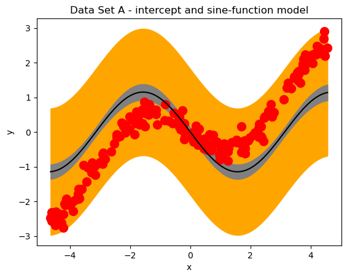

```python
fig, ax = plt.subplots()

# prediction interval
ax.fill_between( dfA_viz.x,
                 pred_viz_A_summary_2.obs_ci_lower, pred_viz_A_summary_2.obs_ci_upper,
                 facecolor='orange', edgecolor='orange')

# confidence interval
ax.fill_between( dfA_viz.x,
                 pred_viz_A_summary_2.mean_ci_lower, pred_viz_A_summary_2.mean_ci_upper,
                 facecolor='grey', edgecolor='grey')

# predicted TREND - average output
ax.plot( dfA_viz.x, pred_viz_A_summary_2['mean'], color='k' )

# include the training data as a scatter plot
ax.scatter( dfA.x, dfA.y, color='r', s=100)

# set the labels
ax.set_xlabel('x')
ax.set_ylabel('y')
ax.set_title('Data Set A - intercept and sine-function model')

# show the plot
plt.show()
```

### 4h)

Next, you must make predictions on the new data set, `dfA_viz`, with the model with **additive** linear and sine-function features `fit_A_3`.

You must use the appropriate methods to return the predictive trend (mean), the lower and upper bounds on the confidence interval, and the lower and upper bounds on the prediction interval. Assign the predictive summaries to the `pred_viz_A_summary_3` object.

Display the `.head()` associated with `pred_viz_A_summary_3` to the screen.

#### 4h) - SOLUTION

```python
pred_viz_A_summary_3=fit_A_3.get_prediction(dfA_viz).summary_frame()
```

```python
pred_viz_A_summary_3.head()
```

|  | mean | mean_se | mean_ci_lower | mean_ci_upper | obs_ci_lower | obs_ci_upper |
| --- | --- | --- | --- | --- | --- | --- |
| 0 | -2.534882 | 0.029247 | -2.592556 | -2.477207 | -2.901814 | -2.167950 |
| 1 | -2.519419 | 0.029096 | -2.576797 | -2.462041 | -2.886304 | -2.152533 |
| 2 | -2.502609 | 0.028934 | -2.559667 | -2.445551 | -2.869445 | -2.135774 |
| 3 | -2.484459 | 0.028760 | -2.541175 | -2.427744 | -2.851242 | -2.117677 |
| 4 | -2.464977 | 0.028575 | -2.521327 | -2.408627 | -2.831703 | -2.098251 |

### 4i)

You must now visualize the predictions associated with `fit_A_3` on the new data set.

You must include the prediction interval as an orange ribbon, the confidence interval as a grey ribbon, and the predictive trend (mean) as a black line.

Include the training points as small red markers from a scatter plot.

Is the predictive trend consistent with the features associated with `fit_A_3`?

Comment on the prediction interval size relative to the confidence interval size.

#### 4i) - SOLUTION

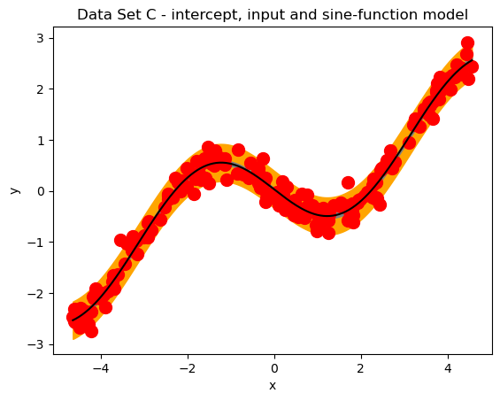

```python
fig, ax = plt.subplots()

# prediction interval
ax.fill_between( dfA_viz.x,
                 pred_viz_A_summary_3.obs_ci_lower, pred_viz_A_summary_3.obs_ci_upper,
                 facecolor='orange', edgecolor='orange')

# confidence interval
ax.fill_between( dfA_viz.x,
                 pred_viz_A_summary_3.mean_ci_lower, pred_viz_A_summary_3.mean_ci_upper,
                 facecolor='grey', edgecolor='grey')

# predicted TREND - average output
ax.plot( dfA_viz.x, pred_viz_A_summary_3['mean'], color='k' )

# include the training data as a scatter plot
ax.scatter( dfA.x, dfA.y, color='r', s=100)

# set the labels
ax.set_xlabel('x')
ax.set_ylabel('y')
ax.set_title('Data Set C - intercept, input and sine-function model')

# show the plot
plt.show()
```

### 4j)

Lastly, you must make predictions on the new data set, `dfA_viz`, with the model that includes **main effects** and **interactions** for the linear and sine-function features `fit_A_4`.

You must use the appropriate methods to return the predictive trend (mean), the lower and upper bounds on the confidence interval, and the lower and upper bounds on the prediction interval. Assign the predictive summaries to the `pred_viz_A_summary_4` object.

Display the `.head()` associated with `pred_viz_A_summary_4` to the screen.

#### 4j) - SOLUTION

```python
pred_viz_A_summary_4=fit_A_4.get_prediction(dfA_viz).summary_frame()
```

```python
pred_viz_A_summary_4.head()
```

|  | mean | mean_se | mean_ci_lower | mean_ci_upper | obs_ci_lower | obs_ci_upper |
| --- | --- | --- | --- | --- | --- | --- |
| 0 | -2.526958 | 0.038538 | -2.602958 | -2.450957 | -2.898033 | -2.155883 |
| 1 | -2.511592 | 0.038225 | -2.586974 | -2.436210 | -2.882541 | -2.140644 |
| 2 | -2.494892 | 0.037879 | -2.569591 | -2.420192 | -2.865702 | -2.124081 |
| 3 | -2.476862 | 0.037501 | -2.550817 | -2.402908 | -2.847523 | -2.106201 |
| 4 | -2.457511 | 0.037093 | -2.530661 | -2.384362 | -2.828012 | -2.087010 |

### 4k)

Finally, you must visualize the predictions associated with `fit_A_4` on the new data set.

You must include the prediction interval as an orange ribbon, the confidence interval as a grey ribbon, and the predictive trend (mean) as a black line.

Include the training points as small red markers from a scatter plot.

Is the predictive trend consistent with the features associated with `fit_A_4`?

Comment on the prediction interval size relative to the confidence interval size.

#### 4k) - SOLUTION

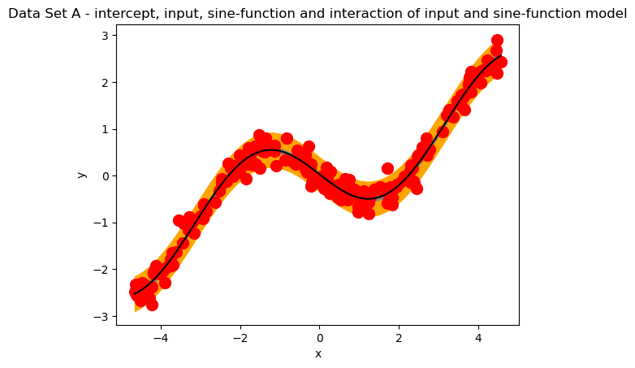

```python
fig, ax = plt.subplots()

# prediction interval
ax.fill_between( dfA_viz.x,
                 pred_viz_A_summary_4.obs_ci_lower, pred_viz_A_summary_4.obs_ci_upper,
                 facecolor='orange', edgecolor='orange')

# confidence interval
ax.fill_between( dfA_viz.x,
                 pred_viz_A_summary_4.mean_ci_lower, pred_viz_A_summary_4.mean_ci_upper,
                 facecolor='grey', edgecolor='grey')

# predicted TREND - average output
ax.plot( dfA_viz.x, pred_viz_A_summary_4['mean'], color='k' )

# include the training data as a scatter plot
ax.scatter( dfA.x, dfA.y, color='r', s=100)

# set the labels
ax.set_xlabel('x')
ax.set_ylabel('y')
ax.set_title('Data Set A - intercept, input, sine-function and interaction of input and sine-function model')

# show the plot
plt.show()
```

### 4l)

You fit multiple models of varying complexity for this application. Although the data consists of a single numeric input, you derived multiple features from that input in several of the models.

How would you describe the general behavior of the **uncertainty intervals** as more features were included in the models, for this application? Did the additional features seem to help explain output behavior? Were the predictions consistent with the training data?

Do you think the predictive trends are consistent with the **general** output to input behavior for this application?

Type your responses in a markdown cell below.

#### 4l) - SOLUTION

## Problem 05

The previous problems involved a single input from a synthetic data set designed specifically for this assignment. You examined the features associated with mutliple models and visualized the predictive behavior due to those features. But, you might be thinking, that's not a real problem! So, let's shift gears and work with a real data set to practice generating features in real applications!

You will work a Concrete Compressive Strength data set. This data set is relatively popular for practicing training regression models and is available online from multiple sources. The data were originally available on the [UCI Machine Learning Repository](https://archive.ics.uci.edu/dataset/165/concrete+compressive+strength), but the [specific version](https://modeldata.tidymodels.org/reference/concrete.html) you will work with is based on the data available from the `modeldata` package from the R statistical programming language. You do not need to read either of the references to work with the data in this assignment. They are provided if you wish you learn more about the data.

You will begin by visually exploring the concrete data. You will then execute two different preprocessing pipelines on the inputs. Lastly, you examine the number of features associated with different types of features derived from the inputs. You will not fit models for this data set in this assignment. Fitting and assessing is reserved for another assignment. This assignment is focused on feature generation, as stated in the assignment introduction.

### 5a)

The concrete data file name is assigned to the `concrete_path` object in the cell below. The file name assumes that you have downloaded the `hw05_concrete_data.csv` file into the same working directory as this notebook.

```python
concrete_path = 'hw05_concrete_data.csv'
```

The data set consists of 9 columns. The output you will predict is named `compressive_strength`. All other columns in the data set are inputs. All 9 columns are numeric variables and thus this application only consists of numeric inputs!

Read in the data using the appropriate Pandas function and assign the result to the `dfconcrete` object. Display the `.info()` method to confirm the data have been read in correctly.

#### 5a) - SOLUTION

```python
dfconcrete=pd.read_csv(concrete_path)
```

```python
dfconcrete.info()
```

```
<class 'pandas.core.frame.DataFrame'>
RangeIndex: 992 entries, 0 to 991
Data columns (total 9 columns):
 #   Column                Non-Null Count  Dtype
---  ------                --------------  -----
 0   cement                992 non-null    float64
 1   blast_furnace_slag    992 non-null    float64
 2   fly_ash               992 non-null    float64
 3   water                 992 non-null    float64
 4   superplasticizer      992 non-null    float64
 5   coarse_aggregate      992 non-null    float64
 6   fine_aggregate        992 non-null    float64
 7   age                   992 non-null    int64
 8   compressive_strength  992 non-null    float64
dtypes: float64(8), int64(1)
memory usage: 69.9 KB
```

### 5b)

Since this is a new data set that we have not worked with before in this class, let's check the essential EDA information! Confirm the data types, check the number of unique values, and check the number of missing entries for each column in `dfconcrete`.

#### 5b) - SOLUTION

```python
dfconcrete.dtypes
```

```
cement                  float64
blast_furnace_slag      float64
fly_ash                 float64
water                   float64
superplasticizer        float64
coarse_aggregate        float64
fine_aggregate          float64
age                       int64
compressive_strength    float64
dtype: object
```

```python
dfconcrete.nunique()
```

```
cement                  278
blast_furnace_slag      185
fly_ash                 156
water                   195
superplasticizer        111
coarse_aggregate        284
fine_aggregate          302
age                      14
compressive_strength    835
dtype: int64
```

```python
dfconcrete.isna().sum()
```

```
cement                  0
blast_furnace_slag      0
fly_ash                 0
water                   0
superplasticizer        0
coarse_aggregate        0
fine_aggregate          0
age                     0
compressive_strength    0
dtype: int64
```

### 5c)

Let's begin by visualizing the marginal distribution of the output, `compressive_strength`. Create a histogram in Seaborn to visualize the distribution of the output.

Does the output cover multiple orders of magnitude and have extreme skew?

#### 5c) - SOLUTION

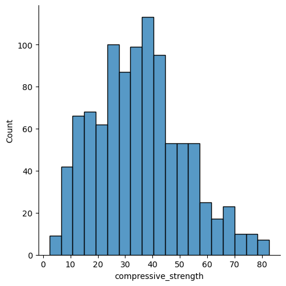

```python
sns.displot(dfconcrete,x='compressive_strength', kind='hist')
plt.show()
```

The ouput overall is close to a bell shape, and the skew is not that bad, so it doesn't have a extreme skew.

### 5d)

Let's now visually explore the inputs beginning by checking their magnitude and scales.

Separate the inputs from the output by **dropping** the output variable. Make a deep (hard) copy of the DataFrame and assign the result (which the output dropped) to the `input_concrete_df` object.

Create a boxplot using the Seaborn wide-format plotting options to display summary statistics associated with each input.

Are the inputs roughly the same magnitude the scale?

*HINT*: The `input_concrete_df` will help be useful for creating the plot of the inputs in Seaborn. Also, you will need the input-only DataFrame later!

**IMPORTANT**: The `input_concrete_df` DataFrame must be a deep copy!

#### 5d) - SOLUTION

```python
input_concrete_df=dfconcrete.drop('compressive_strength', axis=1).copy()
```

```python
input_concrete_df.info()
```

```
<class 'pandas.core.frame.DataFrame'>
RangeIndex: 992 entries, 0 to 991
Data columns (total 8 columns):
 #   Column              Non-Null Count  Dtype
---  ------              --------------  -----
 0   cement              992 non-null    float64
 1   blast_furnace_slag  992 non-null    float64
 2   fly_ash             992 non-null    float64
 3   water               992 non-null    float64
 4   superplasticizer    992 non-null    float64
 5   coarse_aggregate    992 non-null    float64
 6   fine_aggregate      992 non-null    float64
 7   age                 992 non-null    int64
dtypes: float64(7), int64(1)
memory usage: 62.1 KB
```

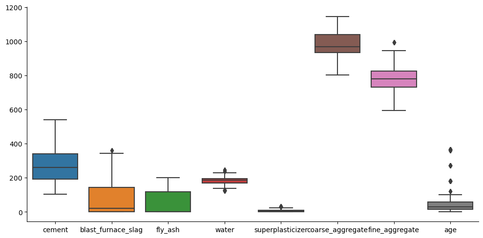

```python
sns.catplot(data=input_concrete_df, kind='box',aspect=2)
plt.show()
```

The inputs are not roughly the same magnitude.

### 5e)

The input marginal distributions must be explored next. You must first **reshape** the data to support facetting in Seaborn. However, you **cannot** reshape or **melt** all variables together. You must **reshape** only the input variables while **holding out** the output variable. Therefore, you must reshape `dfconcrete` and specify the arguments to the `.melt()` method such that the output `compressive_strength` is **not** gathered or *stacked* with the inputs. The final long-format data must have the following columns: `rowid`, `compressive_strength`, `variable`, and `value`. The input names must be contained in the `variable` column.

Assign the reshaped long-format data to `lfconcrete`. Display the `.info()` method to the screen and display the `.value_counts()` method applied to `variable` to confirm the reshaping was performed correctly.

#### 5e) - SOLUTION

```python
lfconcrete=dfconcrete.reset_index().rename(columns={'index':'rowid'}).\
    melt(id_vars=['rowid','compressive_strength'])
```

```python
lfconcrete.info()
```

```
<class 'pandas.core.frame.DataFrame'>
RangeIndex: 7936 entries, 0 to 7935
Data columns (total 4 columns):
 #   Column                Non-Null Count  Dtype
---  ------                --------------  -----
 0   rowid                 7936 non-null   int64
 1   compressive_strength  7936 non-null   float64
 2   variable              7936 non-null   object
 3   value                 7936 non-null   float64
dtypes: float64(2), int64(1), object(1)
memory usage: 248.1+ KB
```

```python
lfconcrete.variable.value_counts()
```

```
variable
cement                992
blast_furnace_slag    992
fly_ash               992
water                 992
superplasticizer      992
coarse_aggregate      992
fine_aggregate        992
age                   992
Name: count, dtype: int64
```

### 5f)

Visualize the input marginal distributions as faceted histograms in Seaborn. Each input must be associated with a column facet, and there must be 4 columns per row in the figure. You must set the arguments such that each facet has its own **free** `x` and `y` axis scales. Thus, the axes are **not** shared across the facets.

Are the input distributions roughly symmetric?

*HINT*: Do **not** forget about `common_bins=False`!

#### 5f) - SOLUTION

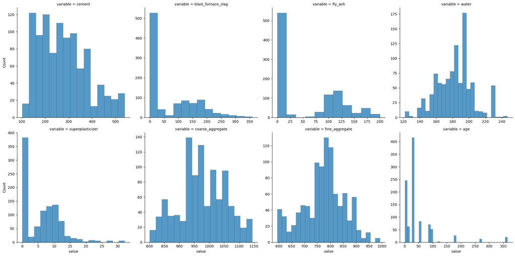

```python
sns.displot(data=lfconcrete, x='value',col='variable',kind='hist',
            col_wrap=4,common_bins=False,
            facet_kws={'sharex':False, 'sharey':False})
plt.show()
```

some of the input distribution are roughly symmetric.

### 5g)

Next, you must visualize the relationship between the output and each input via scatter plots. You must use the reshaped long-format DataFrame, `lfconcrete`, to create a facetted scatter plot such that each input is associated with a column facet. You are therefore visualizing the output to input relationships across all inputs within a single figure. The output must be associated with the y-axis and the input values must be associated with the x-axis. The x-axis scales must not be shared across the facets. You must use 4 column facets per row.

Are there any clear trends visible between the output and inputs?

#### 5g) - SOLUTION

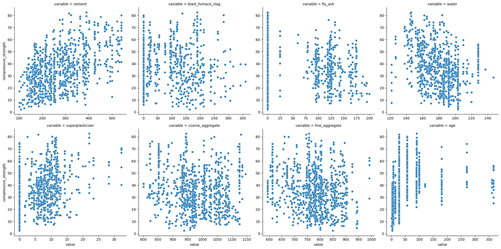

```python
sns.relplot(data=lfconcrete,x='value',y='compressive_strength', col='variable',
            col_wrap=4,
            facet_kws={'sharex':False,'sharey':False})
plt.show()
```

### 5h)

Let's supplement the scatter plot by including a linear trend line within the figure. You must therefore create a faceted trend plot where each input is associated with a facet using the reshaped long-format DataFrame, `lfconcrete`. The output must be associated with the y-axis and the input values must be associated with the x-axis. The x-axis scales must not be shared across the facets. You must use 4 column facets per row.

Did the trend lines help identify any clear trends between the output and inputs?

#### 5h) - SOLUTION

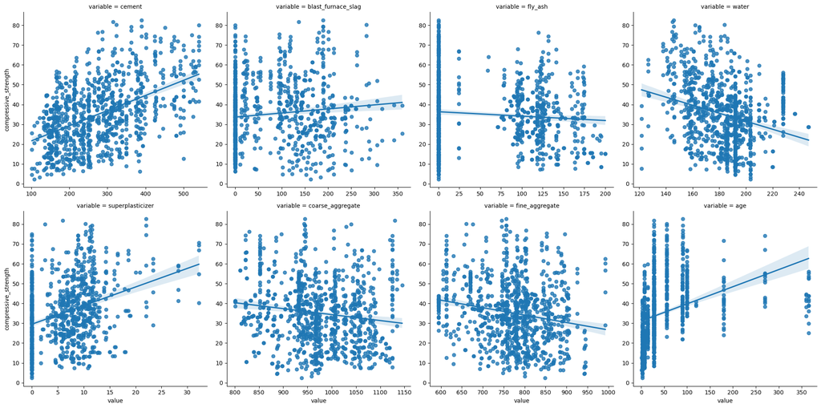

```python
sns.lmplot(data=lfconcrete,x='value', y='compressive_strength', col='variable',
           col_wrap=4,
           facet_kws={'sharex':False,'sharey':False})
plt.show()
```

### 5i)

Although there are more figures we could use to explore the data, you will conclude the quick EDA by checking the **correlation** between the inputs. Create a **correlation plot** using a Seaborn heatmap to show the correlation between all pairs of inputs. The heatmap must be created with the appropriate color bounds and diverging color palette.

Do the inputs appear to be highly correlated in this application?

#### 5i) - SOLUTION

```python
type(input_concrete_df)
```

```
pandas.core.frame.DataFrame
```

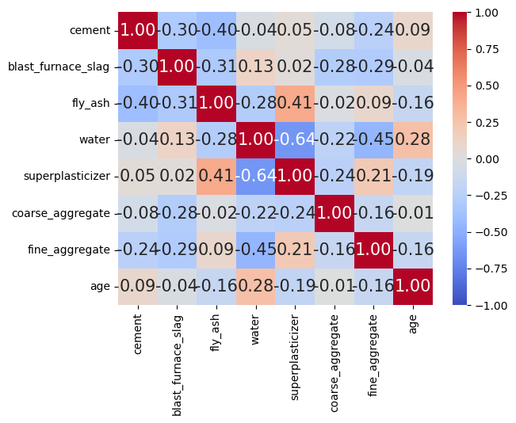

```python
fig, ax = plt.subplots()

sns.heatmap(data = input_concrete_df.corr(numeric_only=True),
            vmin=-1, vmax=1, center=0,
            cmap='coolwarm',
            annot=True, fmt='1.2f',
            annot_kws={'fontsize': 15},
            ax=ax)

plt.show()
```

the input doesn't appear highly correlated.

## Problem 06

Hopefully you noticed that the inputs for this application require some level of preprocessing. Based on your visual exploration, you might be wondering if certain preprocessing actions, such as removing skew, are required. Or, perhaps you not sure how to know if the skew should be removed. When facing such a dilemma, the best approach is to **try mutliple approaches**! Therefore, you should **not** make a choice upfront and just stick with it. Instead, you should identify several possible approaches, apply them, and then quantify their differences at the end. We have not discussed yet how to quantify the **model performance** in CMPINF 2120 (though we did do so in CMPINF 2100). Therefore, this problem is focused on applying the preprocessing rather than ultimately assessing the performance. You will do that in a later assignment.

For this problem though, you will specifically execute two preprocessing pipelines. The first approach standardizes the inputs to remove magnitude and scale effects but **does not** remove skew. The second approach standardizes, applyes the Quantile transformer, and standardizes again in attempt to remove the skew and make sure all preprocessed inputs have the same magnitude scale.

You will use the `Pipeline()` function to manage the preprocessing pipelines. You do **not** need to use `ColumnTransformer()`. This problem therefore relies on programming skills from the previous assignments.

### 6a)

Let's begin by creating the workflow that standardizing the inputs.

Define a `Pipeline()` that consists of a single step named `'std_inputs'` which standardizes the variables. Assign the pipeline to the `stan_wflow` object.

Fit the workflow on the concrete inputs DataFrame, `input_concrete_df`, and assign the fitted pipeline to the `stan_concrete_inputs_fit` object.

#### 6a) - SOLUTION

```python
stan_wflow=Pipeline(steps=[('std_inputs', StandardScaler())])
```

```python
stan_concrete_inputs_fit=stan_wflow.fit(input_concrete_df)
```

### 6b)

Next, let's define the workflow that removes the skew via the Quantile Transformer.

Define a `Pipeline()` that consists of 3 steps named `'std_inputs'`, `'qt'`, and `'std_qt'`. The first step standardizes the inputs, the second step applies the Quantile transformer, and the third step standardizes the transformed inputs. The arguments to Quantile transformer must be set such that the returned distributions are Gaussian. Assign the pipeline to the `qt_wflow` object.

Fit the workflow on the concrete inputs DataFrame, `input_concrete_df`, and assign the fitted pipeline to the `qt_concrete_inputs_fit` object.

#### 6b) - SOLUTION

```python
qt_wflow=Pipeline(steps=[('std_inputs',StandardScaler()),
                         ('qt',QuantileTransformer(output_distribution='normal')),
                         ('std_qt',StandardScaler())])
```

```python
qt_concrete_inputs_fit=qt_wflow.fit(input_concrete_df)
```

### 6c)

Let's apply the fitted preprocessing pipelines to generate the preprocessed inputs!

Standardize the concrete inputs by applying the `.transform()` method for the appropriate pipeline. Assign the result to the `X_input_concrete_stan` object. Convert the object to a Pandas DataFrame and assign the result to the `df_input_concrete_stan` object. Set the column names in `df_input_concrete_stan` to be the same as those in `input_concrete_df`.

Use the Seaborn wide-format plotting options to show a boxplot for all standardized inputs to confirm the standardization worked as expected.

#### 6c) - SOLUTION

```python
X_input_concrete_stan=stan_concrete_inputs_fit.transform(input_concrete_df)
```

```python
df_input_concrete_stan=pd.DataFrame(X_input_concrete_stan,columns=input_concrete_df.columns)
```

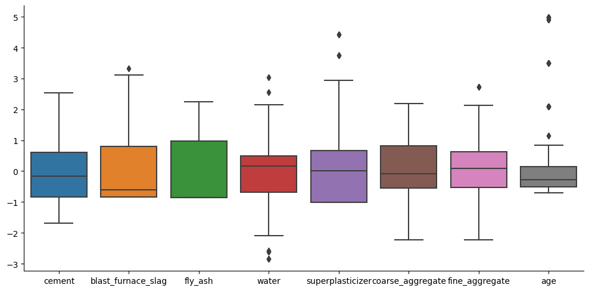

```python
sns.catplot(df_input_concrete_stan, kind='box',aspect=2)
plt.show()
```

### 6d)

Apply the Quantile transformer by applying the `.transform()` method for the appropriate pipeline to the concrete inputs. Assign the result to the `X_input_concrete_qt` object. Convert the object to a Pandas DataFrame and assign the result to the `df_input_concrete_qt` object. Set the column names in `df_input_concrete_qt` to be the same as those in `input_concrete_df`.

Use the Seaborn wide-format plotting options to show a boxplot for all transformed inputs.

#### 6d) - SOLUTION

```python
X_input_concrete_qt=qt_concrete_inputs_fit.transform(input_concrete_df)
```

```python
df_input_concrete_qt=pd.DataFrame(X_input_concrete_qt, columns=input_concrete_df.columns)
```

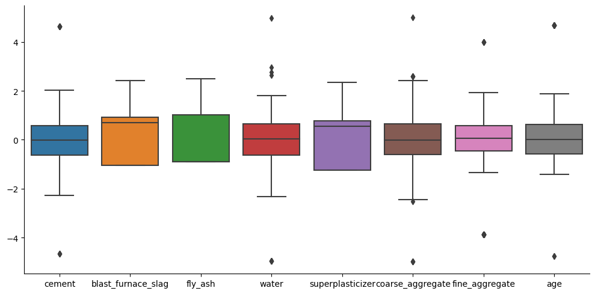

```python
sns.catplot(df_input_concrete_qt,kind='box', aspect=2)
plt.show()
```

### 6e)

THe `df_input_concrete_stan` and `df_input_concrete_qt` objects do **not** contain the output! The objects only contain the transformed inputs! Therefore, neither object can be used for modeling just yet! The output must be **included** as a column to the DataFrames!

Make copies of the two DataFrames before adding the output column. The deep copy associated with `df_input_concrete_stan` must be named `df_ready_concrete_stan`. The deep copy associated with `df_input_concrete_qt` must be named `df_ready_concrete_qt`. Both DataFrames must be deep copies!

Add a column named `compressive_strength` to `df_ready_concrete_stan` and `df_ready_concrete_qt`. The column must be assigned the `compressive_strength` Series from the original `dfconcrete` DataFrame.

#### 6e) - SOLUTION

### 6f)

Although the data are now ready for modeling, let's explore the preprocessed features one last time.

Reshape `df_ready_concrete_stan` to long-format and assign the result to the `lf_ready_concrete_stan`. The output, `compressive_strength` must **not** be gathered with the inputs.

Display the `.info()` method for the long-format data to the screen.

#### 6f) - SOLUTION

### 6g)

Reshape `df_ready_concrete_qt` to long-format and assign the result to the `lf_ready_concrete_qt`. The output, `compressive_strength` must **not** be gathered with the inputs.

Display the `.info()` method for the long-format data to the screen.

#### 6g) - SOLUTION

### 6h)

Let's now visualize the marginal distributions for the preprocessed inputs!

Visualize the input marginal distributions as faceted histograms in Seaborn for the `lf_ready_concrete_stan` DataFrame. Each input must be associated with a column facet, and there must be 4 columns per row in the figure. You must set the arguments such that each facet has its own **free** `x` and `y` axis scales. Thus, the axes are **not** shared across the facets.

Are the input distribution shapes similiar to the original or **raw** distribution shapes?

*HINT*: Do **not** forget about `common_bins=False`!

#### 6h) - SOLUTION

### 6i)

Visualize the input marginal distributions as faceted histograms in Seaborn for the `lf_ready_concrete_qt` DataFrame. Each input must be associated with a column facet, and there must be 4 columns per row in the figure. You must set the arguments such that each facet has its own **free** `x` and `y` axis scales. Thus, the axes are **not** shared across the facets.

Are the input distribution shapes similiar to the original or **raw** distribution shapes?

*HINT*: Do **not** forget about `common_bins=False`!

#### 6i) - SOLUTION

### 6j)

Lastly, let's visualize the relationships between the output and the preprocessed inputs. Begin with the standardized inputs.

You must use the reshaped long-format DataFrame, `lf_ready_concrete_stan`, to create a facetted scatter plot such that each input is associated with a column facet. You are therefore visualizing the output to preprocessed input relationships across all inputs within a single figure. The output must be associated with the y-axis and the input values must be associated with the x-axis. The x-axis scales must not be shared across the facets. You must use 4 column facets per row.

Are the relationships between the output and preprocessed inputs different from those seen with the original or **raw** inputs?

#### 6j) - SOLUTION

### 6k)

Finally, visualize the relationships with the Quantile Transformed inputs.

You must use the reshaped long-format DataFrame, `lf_ready_concrete_qt`, to create a facetted scatter plot such that each input is associated with a column facet. You are therefore visualizing the output to preprocessed input relationships across all inputs within a single figure. The output must be associated with the y-axis and the input values must be associated with the x-axis. The x-axis scales must not be shared across the facets. You must use 4 column facets per row.

Are the relationships between the output and preprocessed inputs different from those seen with the original or **raw** inputs?

#### 6k) - SOLUTION

## Problem 07

You are almost ready to begin modeling the concrete data. The concrete data consists of 8 inputs. You must decide the type of features to derive from those inputs! You must therefore check the number of features generated from the 8 inputs before fitting the models.

This problem is very similar to Problem 02.

You will use the DataFrame that contains the standardized inputs and output, `df_ready_concrete_stan`, to answer the questions in this problem.

### 7a)

Let's begin by examining the features associated with the simplest possible model, the INTERCEPT-ONLY model!

You must generate the output and input feature arrays for an INTERCEPT-ONLY model for `df_ready_concrete_stan` using `dmatrices()` and the formula interface. The output array must be assigned to the `yconcrete_df_0` object and the input feature array must be assigned to the `Xconcrete_df_0` object. You **must** return Pandas DataFrames from `dmatrices()`.

Display the `.head()` of each Pandas DataFrame to the screen.

#### 7a) - SOLUTION

### 7b)

The concrete data set consists of 8 inputs.

How many columns are associated with the `Xconcrete_df_0` feature array? What are the unique values associated with the columns?

Why do the columns have those specific unique values?

Display your answers via code cells below and type your response to the question within a markdown cell.

#### 7b) - SOLUTION

### 7c)

Next, let's consider the "classic best linear regression" model which involves **linear additive features** for all inputs.

The output array must be assigned to the `yconcrete_df_1` object and the input feature array must be assigned to the `Xconcrete_df_1` object. You must return Pandas DataFrames from `dmatrices()`.

Display the `.head()` of the `Xconcrete_df_1` DataFrame to the screen.

#### 7c) - SOLUTION

### 7d)

The concrete data set consists of 8 inputs.

How many coefficients must be estimated for the model associated with the features contained in `Xconcrete_df_1`? What are the interpretations of the coefficients multiplying the features contained in `Xconcrete_df_1`?

Type your response in a markdown cell below.

*HINT*: Your response to this problem should be consistent with your response to 2d).

#### 7d) - SOLUTION

### 7e)

A useful strategy when dealing with multiple inputs is to include **interactions** between the various inputs. However, we may not know ahead of time which pairs are the most critical to focus on. Therefore, we should try **all** pairwise combinations! This model must include the **main effects** for all inputs and all **pairwise** (2nd degree) interactions. You are allowed to use the shortcut within the formula interface for creating the main effects and interactions.

The output array must be assigned to the `yconcrete_df_2` object and the input feature array must be assigned to the `Xconcrete_df_2` object. You must return Pandas DataFrames from dmatrices().

Display the `.head()` of the `Xconcrete_df_2` DataFrame to the screen.

#### 7e) - SOLUTION

### 7f)

The concrete data set consists of 8 inputs.

How many features are associated with `Xconcrete_df_2`?

How many coefficients must be estimated for the model associated with the features contained in `Xconcrete_df_2`?

Type your response in a markdown cell below.

#### 7f) - SOLUTION

### 7g)

The last lecture example discussed how to create higher degrees of interactions. It showed how the formula interface includes shortcuts to greatly streamline increasing the degree of interaction. Let's conclude this example by jumping straight to a model to that consists of up to and including 5th degree interactions. Therefore, this model includes all main effects, pairwise interactions, triplet interactions, 4-way interactions, and 5-way interactioins! This model has a lot of interactions!

The output array must be assigned to the `yconcrete_df_5` object and the input feature array must be assigned to the `Xconcrete_df_5` object. You must return Pandas DataFrames from dmatrices().

Display the `.head()` of the `Xconcrete_df_5` DataFrame to the screen.

#### 7g) - SOLUTION

### 7h)

The concrete data set consists of 8 inputs.

How many features are associated with `Xconcrete_df_5`?

How many coefficients must be estimated for the model associated with the features contained in `Xconcrete_df_5`?

Type your response in a markdown cell below.

#### 7h) - SOLUTION

### 7i)

This problem focused on examining the **number** of features associated with a formula. The number of features were confirmed **before** fitting models thanks to `dmatrices()`. However, you only used the data that contained the standardized inputs and not the data that contained the Quantile transformed inputs. In truth, this problem could have been completed using the original or **raw** inputs

Why does it not matter whether the inputs are preprocessed or not when we are focused on checking the **number of features** derived from the inputs?

Type your response in a markdown cell below.

#### 7i) - SOLUTION

## Problem 08

This week shifted gears from exploring and finding patterns in data to working with predictive models. We specifically focused on linear models for regression.

Your final project **must** be a predictive modeling application. However, there are many different types of predictive modeling applications! Regression is one just type!

You do not need to explore your potential project data for this assignment. Instead, you must state if your project is a regression task, classification task, count data, or time series application. If you are not sure, then state so.

You must state the number of inputs involved and the state the number of numeric vs non-numeric inputs. Based on the exploration you have done up to this point, which of the preprocessing actions do you think will be most relevant to your application?

Type your response in a markdown cell below.

#### 8) - SOLUTION